# atividade02

**Disciplina:** Aprendizado Supervisionado Aplicado a Dados Biológicos e de Saúde  
**Professor:** Prof. Dr. Ricardo Puziol de Oliveira  
**Aluno:** Thiago Moraes Rizzieri

## 1 **Atividade Prática 2.1**

Considere o conjunto de dados `PimaIndiansDiabetes`, disponível na biblioteca `mlbench`, utilizado em estudos de saúde e epidemiologia para análise de fatores associados ao diabetes mellitus tipo 2. Esta base, em particular, contém informações clínicas e laboratoriais de mulheres adultas, incluindo variáveis numéricas relacionadas a medidas fisiológicas e um desfecho binário que indica a presença ou ausência de diabetes. Diante dessas características, e utilizando o ambiente R, responda aos itens a seguir referentes à primeira etapa da AED, correspondente à *visualização da estrutura e dos tipos de dados*.

**(a)** Carregue o conjunto de dados `PimaIndiansDiabetes` e identifique:

- O número total de observações e de variáveis.
- Os nomes das variáveis e sua organização na base de dados.
- Indique quais funções do R são mais adequadas para essa inspeção estrutural inicial.

**(b)** Examine os tipos de dados associados a cada variável (por exemplo, numérico, inteiro, fator). Com base nessa inspeção:

- Classifique as variáveis em contínuas, discretas e categóricas.
- Identifique o papel de cada variável no contexto de um estudo em saúde (por exemplo, variável resposta, covariável clínica ou fator de risco).

**(c)** Verifique a presença de valores ausentes ou de valores que possam indicar codificações especiais (por exemplo, zeros em variáveis fisiológicas que não admitem esse valor).

**(d)** Utilize funções de inspeção estrutural para:

- Obter um resumo geral da base.
- Identificar possíveis variáveis que necessitem de transformação de tipo (por exemplo, conversão de variável resposta para fator).
- Discuta por que essa etapa é fundamental antes da sumarização estatística ou da visualização gráfica propriamente dita.

### 1.1 **Solução**

**(a)** Primeiramente, vamos carregar os dados:

```r
library(mlbench)
data("PimaIndiansDiabetes")
dados <- PimaIndiansDiabetes
head(dados)
```

```
  pregnant glucose pressure triceps insulin mass pedigree age diabetes
1        6     148       72      35       0 33.6    0.627  50      pos
2        1      85       66      29       0 26.6    0.351  31      neg
3        8     183       64       0       0 23.3    0.672  32      pos
4        1      89       66      23      94 28.1    0.167  21      neg
5        0     137       40      35     168 43.1    2.288  33      pos
6        5     116       74       0       0 25.6    0.201  30      neg
```

Uma forma fácil de observar a estrutura das colunas contidas em um dataframe é utilizando a função `str()` do pacote base do R ou então a função `glimpse()` do dplyr.

```r
library(dplyr)
glimpse(dados, width = 60)
```

```
Rows: 768
Columns: 9
$ pregnant <dbl> 6, 1, 8, 1, 0, 5, 3, 10, 2, 8, 4, 10, 10,…
$ glucose  <dbl> 148, 85, 183, 89, 137, 116, 78, 115, 197,…
$ pressure <dbl> 72, 66, 64, 66, 40, 74, 50, 0, 70, 96, 92…
$ triceps  <dbl> 35, 29, 0, 23, 35, 0, 32, 0, 45, 0, 0, 0,…
$ insulin  <dbl> 0, 0, 0, 94, 168, 0, 88, 0, 543, 0, 0, 0,…
$ mass     <dbl> 33.6, 26.6, 23.3, 28.1, 43.1, 25.6, 31.0,…
$ pedigree <dbl> 0.627, 0.351, 0.672, 0.167, 2.288, 0.201,…
$ age      <dbl> 50, 31, 32, 21, 33, 30, 26, 29, 53, 54, 3…
$ diabetes <fct> pos, neg, pos, neg, pos, neg, pos, neg, p…
```

Com esse código, podemos observar que temos um total de 768 observações e 9 variáveis, sendo que `pregnant` é uma variável do tipo double (numérica), assim como as variáveis `glucose`, `pressure`, `triceps`, `insulin`, `mass`, `pedigree` e `age`. Além dessas, temos a variável `diabetes` que é do tipo fator.

**(b)** Classifiquemos as variáveis:

- **pregnant**: variável numérica discreta. Representa uma covariável clínica.
- **glucose**: variável numérica discreta. Representa um fator de risco, pois na verdade os valores altos de glicose são o critério principal para o diagnóstico médico da diabetes.
- **pressure**: variável numérica discreta. Representa uma covariável clínica.
- **triceps**: variável numérica discreta. Representa uma covariável clínica.
- **insulin**: variável numérica discreta. Representa um fator de risco, pois como a insulina é o hormônio responsável por pegar a glicose no sangue e colocá-la dentro das células, essa variável acaba sendo praticamente um sintoma de que a pessoa possui diabetes.
- **mass**: variável numérica contínua. Representa um fator de risco, pois o excesso de gordura corporal pode causar resistência à insulina.
- **pedigree**: variável numérica contínua. Representa um fator de risco, pois, pelo que entendi, representa predisposição genética.
- **age**: variável numérica discreta. Representa uma covariável clínica.
- **diabetes**: variável categórica. Representa a variável resposta desta pesquisa, indicando se o teste da paciente foi positivo ou negativo em relação a diabetes.

**(c)** Vamos usar a função `is.na()` para valores ausentes e verificar se há zeros em algumas variáveis.

Primeiramente em relação aos NAs:

```r
colSums(is.na(dados))
```

```
pregnant  glucose pressure  triceps  insulin     mass pedigree      age
       0        0        0        0        0        0        0        0
diabetes
       0
```

Felizmente estes dados aparentam não possuir nenhum valor ausente em nenhuma das variáveis. A princípio isso é uma notícia boa.

Mas vamos agora analisar se há valores zeros.

```r
colSums(dados == 0)
```

```
pregnant  glucose pressure  triceps  insulin     mass pedigree      age
     111        5       35      227      374       11        0        0
diabetes
       0
```

Apesar de não haver NAs nas nossas variáveis, existem muitos zeros em variáveis fisiológicas que não deveriam admitir esse valor. Isso inclui:

- glucose (5 zeros): Ninguém vivo tem zero de glicose no sangue (isso seria incompatível com a vida).
- pressure (35 zeros): Pressão arterial diastólica zero significa ausência de batimento cardíaco.
- triceps (227 zeros): É a espessura da dobra cutânea (gordura sob a pele). Por mais magra que a pessoa seja, é impossível a espessura ser exatamente zero milímetros.
- mass (11 zeros): É o Índice de Massa Corporal (IMC). Um IMC de zero significa que a pessoa não tem peso algum.
- insulin (374 zeros): Embora diabéticos tipo 1 possam ter níveis baixíssimos, no contexto deste exame laboratorial específico do banco de dados (insulina sérica de 2 horas), o zero foi usado pela equipe de coleta para indicar que o exame não foi realizado ou a amostra foi perdida. Observemos que quase metade do banco (374 de 768) tem esses “zeros”.

Ou seja, isso significa que os zeros são na verdade NAs disfarçados.

**(d)** Aplicando `dfSummary()`:

```r
library(summarytools)
dfSummary(dados)
```

```
Data Frame Summary
dados
Dimensions: 768 x 9
Duplicates: 0

------------------------------------------------------------------------------------------------------------
No   Variable    Stats / Values             Freqs (% of Valid)    Graph                 Valid      Missing
---- ----------- -------------------------- --------------------- --------------------- ---------- ---------
1    pregnant    Mean (sd) : 3.8 (3.4)      17 distinct values    :                     768        0
     [numeric]   min < med < max:                                 :                     (100.0%)   (0.0%)
                 0 < 3 < 17                                       :
                 IQR (CV) : 5 (0.9)                               : : .
                                                                  : : : : . .

2    glucose     Mean (sd) : 120.9 (32)     136 distinct values             :           768        0
     [numeric]   min < med < max:                                         . : :         (100.0%)   (0.0%)
                 0 < 117 < 199                                            : : : .
                 IQR (CV) : 41.2 (0.3)                                    : : : : .
                                                                        : : : : : : :

3    pressure    Mean (sd) : 69.1 (19.4)    47 distinct values              : .         768        0
     [numeric]   min < med < max:                                           : :         (100.0%)   (0.0%)
                 0 < 72 < 122                                               : :
                 IQR (CV) : 18 (0.3)                                      : : : .
                                                                  .       : : : : .

4    triceps     Mean (sd) : 20.5 (16)      51 distinct values    :                     768        0
     [numeric]   min < med < max:                                 :   . :               (100.0%)   (0.0%)
                 0 < 23 < 99                                      : . : :
                 IQR (CV) : 32 (0.8)                              : : : : .
                                                                  : : : : :

5    insulin     Mean (sd) : 79.8 (115.2)   186 distinct values   :                     768        0
     [numeric]   min < med < max:                                 :                     (100.0%)   (0.0%)
                 0 < 30.5 < 846                                   :
                 IQR (CV) : 127.2 (1.4)                           : .
                                                                  : : .

6    mass        Mean (sd) : 32 (7.9)       248 distinct values           :             768        0
     [numeric]   min < med < max:                                         : :           (100.0%)   (0.0%)
                 0 < 32 < 67.1                                          : : :
                 IQR (CV) : 9.3 (0.2)                                   : : : .
                                                                      . : : : :

7    pedigree    Mean (sd) : 0.5 (0.3)      517 distinct values   :                     768        0
     [numeric]   min < med < max:                                 :                     (100.0%)   (0.0%)
                 0.1 < 0.4 < 2.4                                  : :
                 IQR (CV) : 0.4 (0.7)                             : : :
                                                                  : : : : .

8    age         Mean (sd) : 33.2 (11.8)    52 distinct values    :                     768        0
     [numeric]   min < med < max:                                 :                     (100.0%)   (0.0%)
                 21 < 29 < 81                                     :
                 IQR (CV) : 17 (0.4)                              : : . .
                                                                  : : : : . . .

9    diabetes    1. neg                     500 (65.1%)           IIIIIIIIIIIII         768        0
     [factor]    2. pos                     268 (34.9%)           IIIIII                (100.0%)   (0.0%)
------------------------------------------------------------------------------------------------------------
```

Felizmente a variável `diabetes` já aparece sendo do tipo fator, o que não é muito comum. Geralmente esse tipo de variável aparece sendo do tipo categórica e requer ser transformada para o tipo fator.

Porém, a grande presença de zeros afeta significativamente as estatísticas descritivas, puxando as médias e medianas artificialmente para baixo.

Podemos corrigir essa distorção substituindo os zeros incorretos pelo que de fato são, valores ausentes.

```r
dados_corrigidos <- dados %>%
  mutate(across(c(glucose, pressure, triceps, insulin, mass), ~na_if(., 0)))
```

Agora vejamos como isso afeta nas estatísticas descritivas dessas variáveis:

```r
dfSummary(dados_corrigidos,
          plain.ascii = FALSE,
          graph.col = FALSE,
          valid.col = FALSE,
          headings = FALSE)
```

```
-----------------------------------------------------------------------------
No   Variable    Stats / Values               Freqs (% of Valid)    Missing
---- ----------- ---------------------------- --------------------- ---------
1    pregnant\   Mean (sd) : 3.8 (3.4)\       17 distinct values    0\
     [numeric]   min < med < max:\                                  (0.0%)
                 0 < 3 < 17\
                 IQR (CV) : 5 (0.9)

2    glucose\    Mean (sd) : 121.7 (30.5)\    135 distinct values   5\
     [numeric]   min < med < max:\                                  (0.7%)
                 44 < 117 < 199\
                 IQR (CV) : 42 (0.3)

3    pressure\   Mean (sd) : 72.4 (12.4)\     46 distinct values    35\
     [numeric]   min < med < max:\                                  (4.6%)
                 24 < 72 < 122\
                 IQR (CV) : 16 (0.2)

4    triceps\    Mean (sd) : 29.2 (10.5)\     50 distinct values    227\
     [numeric]   min < med < max:\                                  (29.6%)
                 7 < 29 < 99\
                 IQR (CV) : 14 (0.4)

5    insulin\    Mean (sd) : 155.5 (118.8)\   185 distinct values   374\
     [numeric]   min < med < max:\                                  (48.7%)
                 14 < 125 < 846\
                 IQR (CV) : 113.8 (0.8)

6    mass\       Mean (sd) : 32.5 (6.9)\      247 distinct values   11\
     [numeric]   min < med < max:\                                  (1.4%)
                 18.2 < 32.3 < 67.1\
                 IQR (CV) : 9.1 (0.2)

7    pedigree\   Mean (sd) : 0.5 (0.3)\       517 distinct values   0\
     [numeric]   min < med < max:\                                  (0.0%)
                 0.1 < 0.4 < 2.4\
                 IQR (CV) : 0.4 (0.7)

8    age\        Mean (sd) : 33.2 (11.8)\     52 distinct values    0\
     [numeric]   min < med < max:\                                  (0.0%)
                 21 < 29 < 81\
                 IQR (CV) : 17 (0.4)

9    diabetes\   1\. neg\                     500 (65.1%)\          0\
     [factor]    2\. pos                      268 (34.9%)           (0.0%)
-----------------------------------------------------------------------------
```

## 2 **Atividade Prática 2.2**

Considere o conjunto de dados **`NHANES`**, disponibilizado pela biblioteca `NHANES`, o qual deriva do *National Health and Nutrition Examination Survey*, um estudo observacional de base populacional conduzido de forma contínua nos Estados Unidos. Esse inquérito tem como objetivo central avaliar, de maneira integrada, o estado de saúde, o perfil nutricional e as condições socioeconômicas da população civil não institucionalizada. Para atender a esse propósito, a base de dados reúne informações provenientes de entrevistas domiciliares, exames clínicos padronizados e análises laboratoriais, o que resulta em um conjunto amplo e intrinsecamente heterogêneo de variáveis. Essas variáveis abrangem aspectos demográficos, antropométricos, clínicos, laboratoriais e comportamentais, incluindo tanto atributos numéricos contínuos — como idade, peso corporal, estatura, índice de massa corporal e diferentes biomarcadores — quanto variáveis discretas e categóricas, a exemplo de sexo, raça/etnia, nível educacional e estado civil, além de apresentar valores ausentes associados ao próprio desenho amostral e à aplicação de distintos módulos de coleta. Diante dessas características, e utilizando o ambiente R, responda aos itens a seguir referentes à segunda etapa da AED, correspondente à *sumarização dos dados*.

**(a)** Selecione um subconjunto de *variáveis numéricas contínuas* do banco de dados `NHANES` (por exemplo, idade, peso, altura, índice de massa corporal ou medidas laboratoriais). Para cada uma dessas variáveis:

- Obtenha medidas de tendência central.
- Calcule medidas de dispersão apropriadas.
- Identifique valores mínimos, máximos e intervalos.
- Indique quais funções do R são mais adequadas para essa sumarização inicial.

**(b)** Para as variáveis selecionadas em (a), utilize funções de posição relativa para:

- Calcular quartis e percentis selecionados das variáveis numéricas.
- Obter o intervalo interquartílico (IQR).
- Explicar como essas medidas contribuem para a compreensão da variabilidade e da assimetria dos dados em comparação às medidas baseadas na média e no desvio-padrão.

**(c)** Selecione pelo menos *duas variáveis categóricas* (por exemplo, sexo, raça/etnia, escolaridade ou estado civil). Para essas variáveis:

- Construa tabelas de frequências absolutas.
- Obtenha as correspondentes frequências relativas.

**(d)** Para as variáveis selecionadas em (c), investigue a presença de *valores ausentes*, isto é,

- Identifique quais variáveis apresentam maior proporção de dados faltantes.
- Calcule o percentual de valores ausentes por variável.

**(e)** Utilizando funções do pacote `dplyr`, realize uma *sumarização estratificada*, considerando:

- Ao menos três variável numérica.
- Um fator de estratificação (por exemplo, sexo ou grupo etário).

**(f)** Construa *tabelas de contingência* para investigar a associação descritiva entre variáveis categóricas selecionadas no conjunto `NHANES`. Para isso:

- Selecione duas variáveis categóricas (por exemplo, `Gender` × `Diabetes`, ou `Race1` × `Education`).
- Obtenha a tabela de frequências conjuntas por meio de `table()`.
- Calcule proporções por linha e por coluna utilizando `prop.table()` com o argumento `margin`.
- Interprete, em termos descritivos, as diferenças nas distribuições condicionais entre categorias, evitando conclusões inferenciais formais.
- Discuta em que situações tabelas de contingência são mais informativas do que frequências marginais e quais limitações devem ser consideradas quando há categorias com baixa frequência.

**(g)** Utilize a função `mutate()` (biblioteca `dplyr`) para criar *variáveis* e apoiar a sumarização exploratória. Considere, por exemplo:

- A criação de faixas etárias (por exemplo, `AgeGroup`) a partir de `Age`, definindo pontos de corte clinicamente interpretáveis.
- A criação de uma variável indicadora (binária) para sobrepeso/obesidade a partir de `BMI`, segundo um critério previamente definido.
- A recodificação de variáveis categóricas (por exemplo, agregando níveis raros ou reordenando fatores) com o objetivo de tornar as sumarizações mais interpretáveis.

**(h)** Empregue a biblioteca `summarytools` para produzir sumarizações *mais apresentáveis* das variáveis selecionadas nos itens anteriores. Em particular:

- Utilize `dfSummary()` para obter uma visão integrada do conjunto (tipos de variáveis, estatísticas descritivas, frequências e proporção de valores ausentes).
- Aplique `freq()` para sumarizar variáveis categóricas, reportando frequências absolutas e relativas, bem como percentuais cumulativos quando pertinente.
- Utilize `ctable()` para construir tabelas cruzadas (contingência) com apresentação ampliada, incluindo percentuais (por linha, por coluna ou totais), conforme apropriado.
- Discuta as vantagens do uso do `summarytools` em relatórios reprodutíveis (por exemplo, clareza, padronização e controle de apresentação) em comparação às funções base do R (`summary()`, `table()`, `prop.table()`), especialmente em bases heterogêneas como `NHANES`.

### 2.1 **Solução**

Antes de tudo, vamos carregar estes dados:

```r
library(NHANES)
data("NHANES")
dados2 <- NHANES
head(dados2)
```

```
# A tibble: 6 × 76
     ID SurveyYr Gender   Age AgeDecade AgeMonths Race1 Race3 Education
  <int> <fct>    <fct>  <int> <fct>         <int> <fct> <fct> <fct>
1 51624 2009_10  male      34 " 30-39"        409 White <NA>  High School
2 51624 2009_10  male      34 " 30-39"        409 White <NA>  High School
3 51624 2009_10  male      34 " 30-39"        409 White <NA>  High School
4 51625 2009_10  male       4 " 0-9"           49 Other <NA>  <NA>
5 51630 2009_10  female    49 " 40-49"        596 White <NA>  Some College
6 51638 2009_10  male       9 " 0-9"          115 White <NA>  <NA>
# ℹ 67 more variables: MaritalStatus <fct>, HHIncome <fct>, HHIncomeMid <int>,
#   Poverty <dbl>, HomeRooms <int>, HomeOwn <fct>, Work <fct>, Weight <dbl>,
#   Length <dbl>, HeadCirc <dbl>, Height <dbl>, BMI <dbl>,
#   BMICatUnder20yrs <fct>, BMI_WHO <fct>, Pulse <int>, BPSysAve <int>,
#   BPDiaAve <int>, BPSys1 <int>, BPDia1 <int>, BPSys2 <int>, BPDia2 <int>,
#   BPSys3 <int>, BPDia3 <int>, Testosterone <dbl>, DirectChol <dbl>,
#   TotChol <dbl>, UrineVol1 <int>, UrineFlow1 <dbl>, UrineVol2 <int>, …
```

**(a)** Vamos selecionar algumas variáveis numéricas contínuas interessantes.

```r
dados2_vars <- dados2 %>%
  select(Age,Weight,Height,Poverty)
```

Medidas centrais:

```r
dados2_medias <- dados2_vars %>%
  apply(.,2,mean,na.rm = TRUE)

dados2_median <- dados2_vars %>%
  apply(.,2,median,na.rm = TRUE)

library(DescTools)
dados2_moda <- dados2_vars %>%
  apply(.,2,Mode,na.rm = TRUE)

kable(cbind(dados2_medias,dados2_median,dados2_moda), col.names = c("Médias","Medianas","Modas"))
```

|  | Médias | Medianas | Modas |
| --- | --- | --- | --- |
| Age | 36.742100 | 36.0 | 80.0 |
| Weight | 70.981798 | 72.7 | 78.1 |
| Height | 161.877838 | 166.0 | 173.2 |
| Poverty | 2.801844 | 2.7 | 5.0 |

Medidas de dispersão:

```r
dados2_var <- dados2_vars %>%
  apply(.,2,var,na.rm = TRUE)

dados2_sd <- dados2_vars %>%
  apply(.,2,sd,na.rm = TRUE)

ep <- function(x, na.rm = FALSE){
  if (na.rm) {
    x <- na.omit(x)
  }
  sd(x) / sqrt(nrow(dados2))
}

dados2_ep <- dados2_vars %>%
  apply(.,2,ep, na.rm = TRUE)

dados2_IQR <- dados2_vars %>%
  apply(.,2,IQR,na.rm = TRUE)

kable(cbind(dados2_var,dados2_sd,dados2_ep,dados2_IQR), col.names = c("Variâncias", "Desvios-padrão","Erros padrão","IQRs"))
```

|  | Variâncias | Desvios-padrão | Erros padrão | IQRs |
| --- | --- | --- | --- | --- |
| Age | 501.650953 | 22.397566 | 0.2239757 | 37.00 |
| Weight | 848.286446 | 29.125357 | 0.2912536 | 32.80 |
| Height | 407.497471 | 20.186567 | 0.2018657 | 17.70 |
| Poverty | 2.815379 | 1.677909 | 0.0167791 | 3.47 |

Fiz dessa forma, fazendo item por item para treinar, mas também podemos obter algumas estatísticas utilizando funções como `summary()` fornecendo um panorama geral instantâneo:

```r
summary(dados2_vars)
```

```
      Age            Weight           Height         Poverty
 Min.   : 0.00   Min.   :  2.80   Min.   : 83.6   Min.   :0.000
 1st Qu.:17.00   1st Qu.: 56.10   1st Qu.:156.8   1st Qu.:1.240
 Median :36.00   Median : 72.70   Median :166.0   Median :2.700
 Mean   :36.74   Mean   : 70.98   Mean   :161.9   Mean   :2.802
 3rd Qu.:54.00   3rd Qu.: 88.90   3rd Qu.:174.5   3rd Qu.:4.710
 Max.   :80.00   Max.   :230.70   Max.   :200.4   Max.   :5.000
                 NA's   :78       NA's   :353     NA's   :726
```

**(b)** Temos os quantis:

```r
dados2_quantile <- dados2_vars %>%
  apply(.,2,quantile,probs = c(0.25,0.5,0.75),na.rm = TRUE)
dados2_quantile
```

```
    Age Weight Height Poverty
25%  17   56.1  156.8    1.24
50%  36   72.7  166.0    2.70
75%  54   88.9  174.5    4.71
```

E o IQR obtido no item anterior:

```r
dados2_IQR
```

```
    Age  Weight  Height Poverty
  37.00   32.80   17.70    3.47
```

O intervalo interquartílico também é uma medida de dispersão, mostrando a distância entre o primeiro e o terceiro quartil, em que ele mede a dispersão dos 50% centrais dos dados, ignorando valores anômalos (outliers). Também auxilia na visualização da assimetria dos dados, com o quanto cada quartil se distancia da mediana.

Além disso, diferentemente da média e do desvio-padrão, que são altamente sensíveis e puxados por valores extremos, a mediana e o IQR nos fornecem a representação mais realista do ``paciente comum”.

**(c)** Vamos selecionar as variáveis: `Gender`, `Race1` e `Diabetes`:

```r
dados2_cat <- dados2 %>%
  select(Gender,Race1,Diabetes)
```

Temos a tabela de frequência absoluta dada por:

```r
table(dados2_cat)
```

```
, , Diabetes = No

        Race1
Gender   Black Hispanic Mexican White Other
  female   541      293     416  2973   369
  male     512      262     509  2867   356

, , Diabetes = Yes

        Race1
Gender   Black Hispanic Mexican White Other
  female    68       22      27   203    37
  male      63       25      39   247    29
```

E de frequência relativa dada por:

```r
prop.table(table(dados2_cat))
```

```
, , Diabetes = No

        Race1
Gender         Black    Hispanic     Mexican       White       Other
  female 0.054879286 0.029722053 0.042199229 0.301582471 0.037431528
  male   0.051937513 0.026577399 0.051633191 0.290829783 0.036112802

, , Diabetes = Yes

        Race1
Gender         Black    Hispanic     Mexican       White       Other
  female 0.006897951 0.002231690 0.002738892 0.020592412 0.003753297
  male   0.006390749 0.002536011 0.003956178 0.025055792 0.002941773
```

**(d)** Vamos analisar o percentual de NAs de cada variável categórica usada no item anterior:

```r
na_count <- colSums(is.na(dados2_cat))
na_percent <- (na_count / nrow(dados2_cat)) * 100

kable(cbind(`Valores Ausentes` = na_count, `Percentual (%)` = na_percent), digits = 2)
```

|  | Valores Ausentes | Percentual (%) |
| --- | --- | --- |
| Gender | 0 | 0.00 |
| Race1 | 0 | 0.00 |
| Diabetes | 142 | 1.42 |

Conforme a tabela acima, a variável Diabetes apresenta a maior proporção de dados faltantes (1.42%), enquanto que as outras duas analisadas não possuem NAs.

**(e)** Vou selecionar as variáveis numéricas correspondentes à idade, peso e altura, e a variável categórica sendo a etnia.

```r
dados2_grupo <- dados2 %>%
  select(Age,Weight,Height,Race1)
```

Vamos observar a média de cada variável numérica em cada etnia.

```r
resumo <- dados2_grupo %>%
  group_by(Race1) %>%
  summarise(media_idade = mean(Age),
            media_peso = mean(Weight,na.rm = TRUE),
            media_altura = mean(Height,na.rm = TRUE))
kable(resumo)
```

| Race1 | media_idade | media_peso | media_altura |
| --- | --- | --- | --- |
| Black | 33.94486 | 74.71797 | 161.3279 |
| Hispanic | 31.72623 | 65.72726 | 156.2426 |
| Mexican | 27.37635 | 64.78868 | 155.3785 |
| White | 39.80273 | 72.89313 | 164.1409 |
| Other | 32.29032 | 62.12763 | 157.0391 |

**(f)** Estarei utilizando a sugestão `Gender` × `Diabetes`:

```r
dados2_cat <- dados2 %>%
  select(Gender,Diabetes)
```

Temos a tabela de frequências conjuntas:

```r
table(dados2_cat)
```

```
        Diabetes
Gender     No  Yes
  female 4592  357
  male   4506  403
```

E as proporções utilizando o argumento `margin`$=1$:

```r
prop.table(table(dados2_cat), margin = 1)
```

```
        Diabetes
Gender           No        Yes
  female 0.92786421 0.07213579
  male   0.91790589 0.08209411
```

Utilizei a proporção por linha, dessa forma, podemos observar as distribuições condicionais da doença para cada gênero separadamente. Os dados indicam que, nesta amostra, a proporção de pacientes diagnosticados com diabetes é ligeiramente maior no sexo masculino (8.2%) em comparação ao feminino (7.2%).

**(g)** Fiz as mudanças seguindo os seguintes critérios apresentados no próprio código:

```r
dados2 <- dados2 %>%
  mutate(AgeGroup = ifelse(Age <= 18, "Child", ifelse(Age <= 65,"Adult","Elderly")),
         BMIclass = ifelse(BMI <= 18.5, "Underweight", ifelse(BMI <= 24.9,"Healthy", "Overweight")))
```

**(h)** Empregue a biblioteca `summarytools` para produzir sumarizações *mais apresentáveis* das variáveis selecionadas nos itens anteriores. Em particular:

- Utilize `dfSummary()` para obter uma visão integrada do conjunto (tipos de variáveis, estatísticas descritivas, frequências e proporção de valores ausentes).
- Aplique `freq()` para sumarizar variáveis categóricas, reportando frequências absolutas e relativas, bem como percentuais cumulativos quando pertinente.
- Utilize `ctable()` para construir tabelas cruzadas (contingência) com apresentação ampliada, incluindo percentuais (por linha, por coluna ou totais), conforme apropriado.
- Discuta as vantagens do uso do `summarytools` em relatórios reprodutíveis (por exemplo, clareza, padronização e controle de apresentação) em comparação às funções base do R (`summary()`, `table()`, `prop.table()`), especialmente em bases heterogêneas como `NHANES`.

```r
head(dfSummary(dados2))
```

```
Data Frame Summary
dados2
Dimensions: 10000 x 78
Duplicates: 2168

-----------------------------------------------------------------------------------------------------------------
No   Variable    Stats / Values                 Freqs (% of Valid)     Graph                 Valid      Missing
---- ----------- ------------------------------ ---------------------- --------------------- ---------- ---------
1    ID          Mean (sd) : 61944.6 (5871.2)   6779 distinct values   . . . : . : . : : :   10000      0
     [integer]   min < med < max:                                      : : : : : : : : : :   (100.0%)   (0.0%)
                 51624 < 62159.5 < 71915                               : : : : : : : : : :
                 IQR (CV) : 10134.5 (0.1)                              : : : : : : : : : :
                                                                       : : : : : : : : : :

2    SurveyYr    1. 2009_10                     5000 (50.0%)           IIIIIIIIII            10000      0
     [factor]    2. 2011_12                     5000 (50.0%)           IIIIIIIIII            (100.0%)   (0.0%)

3    Gender      1. female                      5020 (50.2%)           IIIIIIIIII            10000      0
     [factor]    2. male                        4980 (49.8%)           IIIIIIIII             (100.0%)   (0.0%)

4    Age         Mean (sd) : 36.7 (22.4)        81 distinct values     : .   . . . .         10000      0
     [integer]   min < med < max:                                      : : : : : : : .       (100.0%)   (0.0%)
                 0 < 36 < 80                                           : : : : : : : : . :
                 IQR (CV) : 37 (0.6)                                   : : : : : : : : : :
                                                                       : : : : : : : : : :

5    AgeDecade   1. ·0-9                        1391 (14.4%)           II                    9667       333
     [factor]    2. ·10-19                      1374 (14.2%)           II                    (96.7%)    (3.3%)
                 3. ·20-29                      1356 (14.0%)           II
                 4. ·30-39                      1338 (13.8%)           II
                 5. ·40-49                      1398 (14.5%)           II
                 6. ·50-59                      1304 (13.5%)           II
                 7. ·60-69                       919 ( 9.5%)           I
                 8. ·70+                         587 ( 6.1%)           I

6    AgeMonths   Mean (sd) : 420.1 (259)        910 distinct values    :     .   .           4962       5038
     [integer]   min < med < max:                                      : : : : : : :         (49.6%)    (50.4%)
                 0 < 418 < 959                                         : : : : : : : : .
                 IQR (CV) : 425 (0.6)                                  : : : : : : : : : .
                                                                       : : : : : : : : : :
-----------------------------------------------------------------------------------------------------------------
```

```r
freq(dados2_cat)
```

```
Frequencies
dados2_cat$Gender
Type: Factor

                Freq   % Valid   % Valid Cum.   % Total   % Total Cum.
------------ ------- --------- -------------- --------- --------------
      female    5020     50.20          50.20     50.20          50.20
        male    4980     49.80         100.00     49.80         100.00
        <NA>       0                               0.00         100.00
       Total   10000    100.00         100.00    100.00         100.00

dados2_cat$Diabetes
Type: Factor

               Freq   % Valid   % Valid Cum.   % Total   % Total Cum.
----------- ------- --------- -------------- --------- --------------
         No    9098     92.29          92.29     90.98          90.98
        Yes     760      7.71         100.00      7.60          98.58
       <NA>     142                               1.42         100.00
      Total   10000    100.00         100.00    100.00         100.00
```

```r
ctable(dados2_cat)
```

```
Cross-Tabulation, Row Proportions
ctable(x = dados2_cat) * structure(2L, levels = c("female", "male", "No", "Yes"), class = "factor")

------------------------ ---------------------------------------------------------------------------- -------------- ------------ ------------ ----------------
                           structure(2L, levels = c("female", "male", "No", "Yes"), class = "factor")             No          Yes         <NA>            Total
  ctable(x = dados2_cat)
                  female                                                                                4592 (91.5%)   357 (7.1%)    71 (1.4%)    5020 (100.0%)
                    male                                                                                4506 (90.5%)   403 (8.1%)    71 (1.4%)    4980 (100.0%)
                   Total                                                                                9098 (91.0%)   760 (7.6%)   142 (1.4%)   10000 (100.0%)
------------------------ ---------------------------------------------------------------------------- -------------- ------------ ------------ ----------------
```

O uso do summarytools em relatórios reprodutíveis traz a vantagem de padronizar a apresentação visual e consolidar várias informações em uma única chamada. Em bases de dados grandes e heterogêneas como o NHANES, funções como dfSummary() calculam simultaneamente estatísticas descritivas, contagem de valores únicos e proporção de NAs, algo que exigiria dezenas de linhas de código usando apenas o R base.

## 3 **Atividade Prática 2.3**

Considere, novamente, o conjunto de dados **`NHANES`**, disponibilizado pela biblioteca `NHANES`, o qual deriva do *National Health and Nutrition Examination Survey*, um estudo observacional de base populacional conduzido de forma contínua nos Estados Unidos. As variáveis desta base abrangem aspectos demográficos, antropométricos, clínicos, laboratoriais e comportamentais, incluindo tanto atributos numéricos contínuos quanto variáveis discretas e categóricas, além de apresentar valores ausentes associados ao próprio desenho amostral e à aplicação de distintos módulos de coleta. Diante dessas características, e utilizando o ambiente R, responda aos itens a seguir referentes à terceira etapa da AED, correspondente à *visualização gráfica dos dados*.

**(a) Histograma.**

- Selecione uma variável numérica contínua (por exemplo, `BMI` ou `TotChol`).
- Construa um histograma utilizando `hist()`.
- Refaça o histograma variando o argumento `breaks` (por exemplo, `"Sturges"` e `"FD"`).
- Discuta como a escolha do particionamento em classes influencia a percepção da forma da distribuição.

**(b) Boxplot.**

- Construa um boxplot de uma variável numérica (por exemplo, `BMI`) estratificada por uma variável categórica (por exemplo, `Gender` ou `Diabetes`) utilizando `boxplot()`.
- Identifique, de forma descritiva, diferenças de posição (mediana), dispersão (IQR) e presença de valores extremos entre os grupos.

**(c) Gráfico de Violino com `ggplot2`.**

- Reproduza a comparação do item (b) usando `ggplot()` e `geom_violin()`, inclua rótulos informativos com `labs()` e ajuste um tema com `theme()`.
- Discuta, em termos exploratórios, quais informações adicionais o gráfico de violino fornece em relação ao boxplot.

**(d) Gráfico de Barras.**

- Selecione uma variável categórica (por exemplo, `Education` ou `Race1`).
- Construa um gráfico de barras com `barplot()` a partir de uma tabela de frequências (`table()`).
- Produza uma versão do gráfico em termos de frequências relativas e compare as interpretações obtidas.

**(e) Tabela de Contingência.**

- Construa uma tabela de contingência entre duas variáveis categóricas (por exemplo, `Diabetes` × `Gender`, ou `SmokeNow` × `Education`) usando `table()`.
- Calcule proporções por linha e por coluna com `prop.table()`.
- Construa uma representação gráfica adequada para comparar as distribuições condicionais (por exemplo, barras lado a lado).

**(f) Diagrama de Dispersão.**

- Selecione duas variáveis numéricas (por exemplo, `Weight` e `Height`, ou `BMI` e `TotChol`).
- Construa um gráfico de dispersão com `plot(x, y)`.
- Construa uma versão do gráfico de dispersão com `ggplot()` e `geom_point()`, discutindo possíveis padrões de associação, heterocedasticidade e presença de observações influentes.

**(g) Matriz de Dispersão.**

- Selecione um subconjunto com pelo menos quatro variáveis numéricas contínuas (por exemplo, `Age`, `BMI`, `TotChol`, `BPSysAve`).
- Construa uma matriz de dispersão com `pairs()`.
- Identifique relações bivariadas que mereçam investigação adicional e discuta possíveis sinais de colinearidade.

**(h) Visualização de Dados Ausentes.**

- Para as variáveis utilizadas nos itens anteriores, investigue e represente graficamente o padrão de valores ausentes (por exemplo, comparando a proporção de `NA` entre variáveis, ou estratificando por grupos).
- Discuta como a presença de dados faltantes pode afetar a interpretação dos gráficos produzidos.

### 3.1 **Solução**

**(a)** Para o histograma utilizei a variável `BMI`:

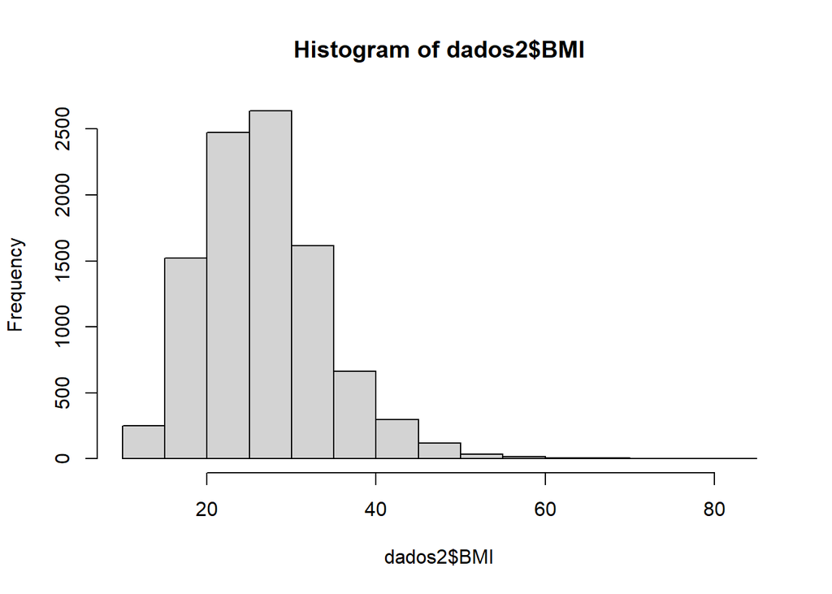

```r
hist(dados2$BMI)
```

Agora com o argumento `breaks`=FD.

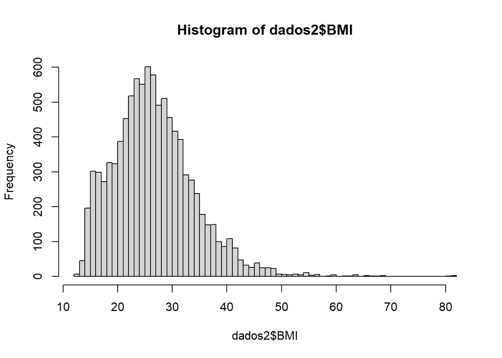

```r
hist(dados2$BMI, breaks = 'FD')
```

A escolha do método de particionamento (breaks) altera a “resolução” da visualização. Ao utilizar o método “FD” (Freedman-Diaconis), o histograma fica com mais barras, revelando micro-padrões.

**(b)**

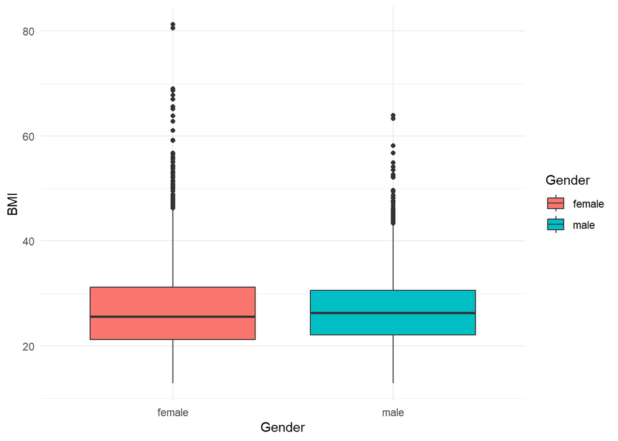

```r
library(ggplot2)
ggplot(dados2, aes(x = Gender, y = BMI, fill = Gender))+
  geom_boxplot()+
  theme_minimal()
```

As medianas de BMI entre os sexos masculino e feminino são muito próximas, ambas levemente acima de 25. O IQR também é semelhante, indicando variabilidade parecida nos 50% centrais. No entanto, o grupo feminino apresenta uma quantidade consideravelmente maior de valores extremos (outliers) na parte superior do gráfico, chegando a ultrapassar o valor 80 de BMI.

**(c)**

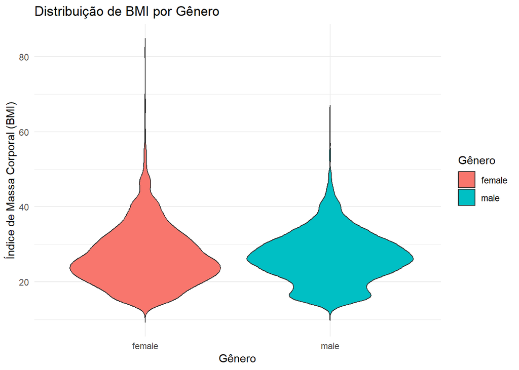

```r
ggplot(dados2, aes(x = Gender, y = BMI, fill = Gender)) +
  geom_violin(trim = FALSE) +
  labs(title = "Distribuição de BMI por Gênero",
       x = "Gênero",
       y = "Índice de Massa Corporal (BMI)",
       fill = "Gênero") +
  theme_minimal()
```

O gráfico de violino revela a densidade e o formato real da distribuição, além das informações obtidas com o boxplot.

**(d)** Vou utilizar as etnias para realizar os gráficos.

Temos o gráfico de barras para a frequência absoluta:

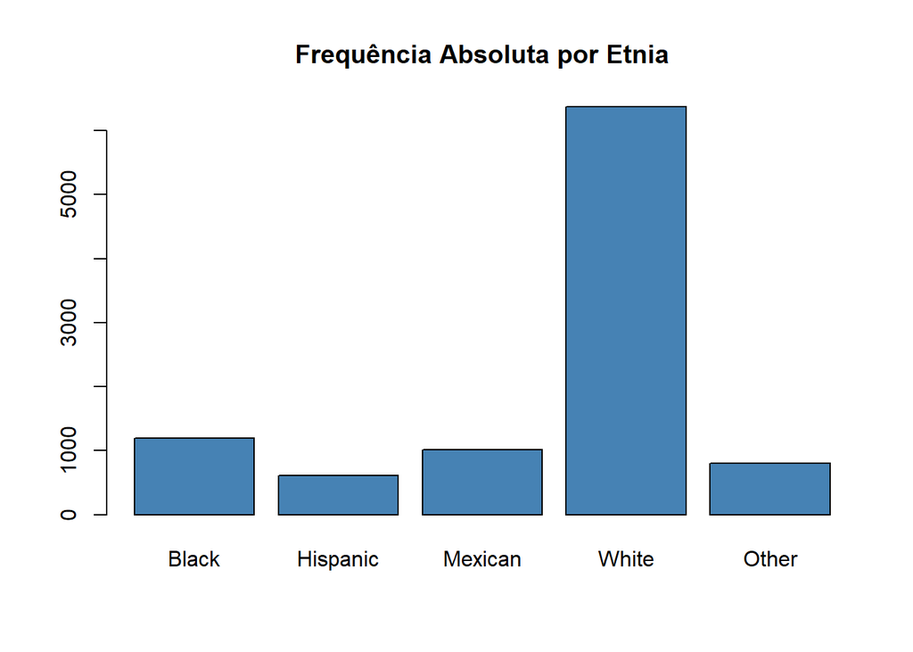

```r
tabela_race <- table(dados2$Race1)
barplot(tabela_race, main = "Frequência Absoluta por Etnia", col = "steelblue")
```

E o de frequência relativa:

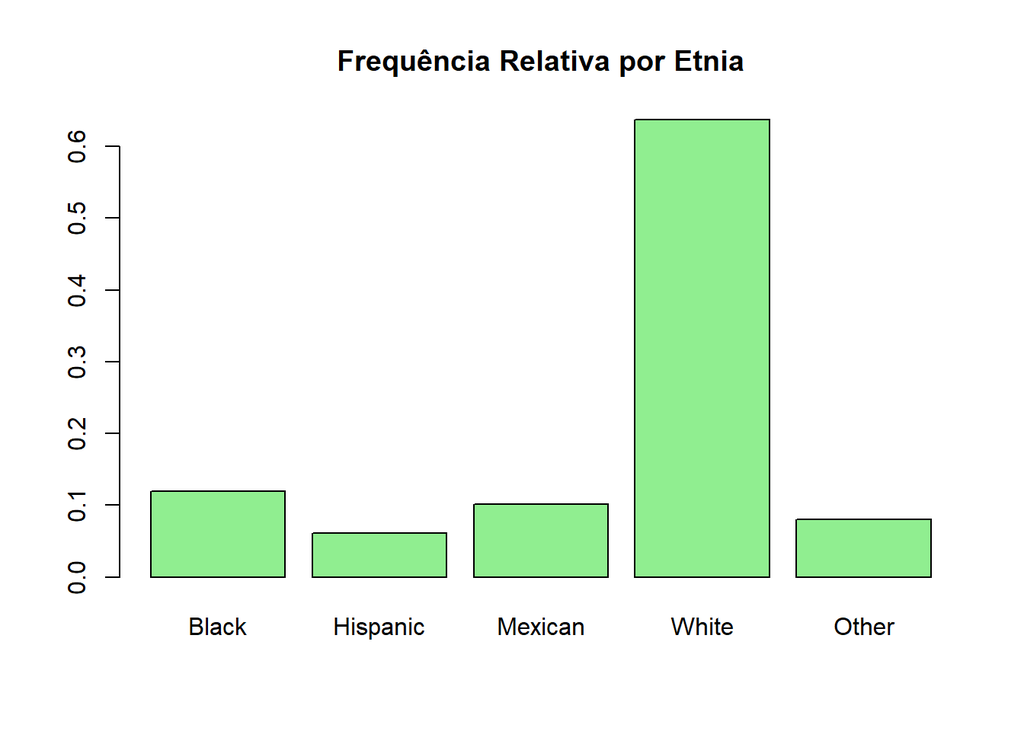

```r
tabela_race_rel <- prop.table(tabela_race)
barplot(tabela_race_rel, main = "Frequência Relativa por Etnia", col = "lightgreen")
```

O formato dos dois gráficos é idêntico. A diferença fica na interpretação do eixo Y, sendo que a frequência absoluta nos mostra o volume real da amostra coletada, enquanto a frequência relativa nos permite entender a representatividade percentual de cada grupo.

**(e)**

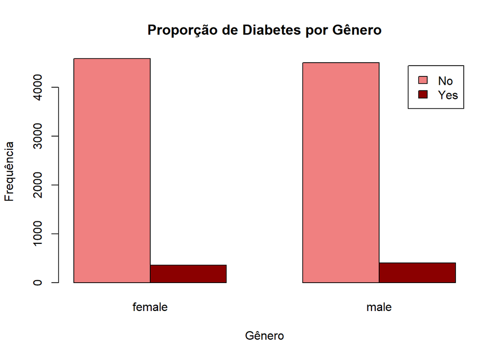

```r
tab_contingencia <- table(dados2$Diabetes, dados2$Gender)

barplot(tab_contingencia, beside = TRUE,
        col = c("lightcoral", "darkred"),
        legend = rownames(tab_contingencia),
        main = "Proporção de Diabetes por Gênero",
        xlab = "Gênero", ylab = "Frequência")
```

Visualmente é quase imperceptível a diferença da proporção de diabetes, mas vimos anteriormente que a proporção de diabetes entre os homens é singelamente superior.

**(f)** Utilizando `plot()`:

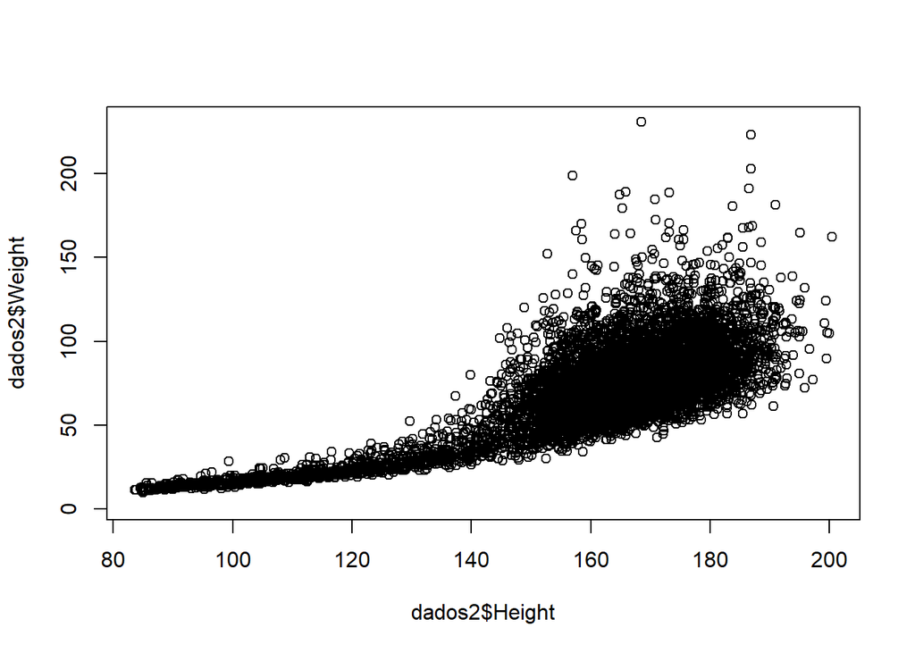

```r
plot(dados2$Height, dados2$Weight)
```

Utilizando `geom_point()`:

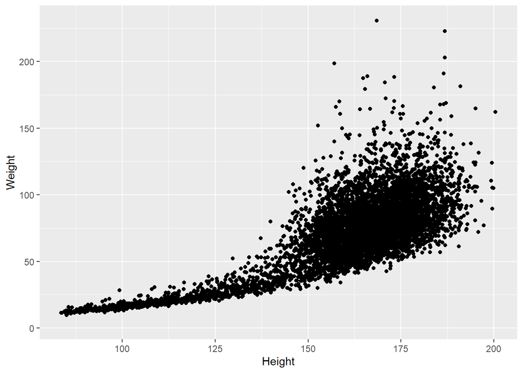

```r
ggplot(dados2, aes(x=Height, y=Weight))+
  geom_point()
```

**(g)**

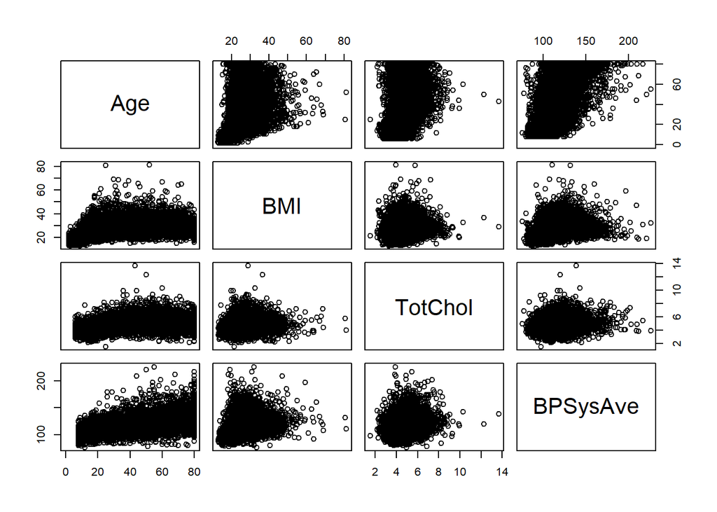

```r
dados2_vars <- dados2 %>%
  select(Age, BMI, TotChol, BPSysAve)

pairs(dados2_vars)
```

Apesar de ser um gráfico bem poluído, podemos enxergar alguns padrões. Nota-se uma correlação positiva entre idade e BPSysAve, indicando que a pressão sistólica tende a subir ao longo de toda a vida. Além disso, aparenta existir uma correlação não-linear entre idade e BMI: observa-se um crescimento íngreme do BMI nas duas primeiras décadas de vida que se estabiliza em uma nuvem de alta dispersão na vida adulta.

**(h)** Irei avaliar as variáveis numéricas:

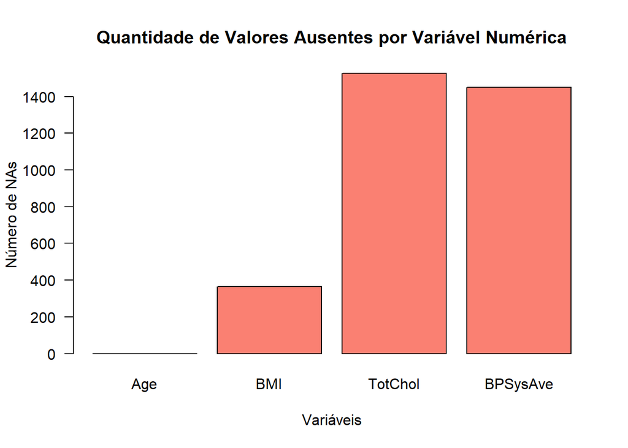

```r
contagem_na <- colSums(is.na(dados2_vars))

barplot(contagem_na,
        main = "Quantidade de Valores Ausentes por Variável Numérica",
        col = "salmon",
        ylab = "Número de NAs",
        xlab = "Variáveis",
        las = 1)
```

A presença desses valores ausentes afeta diretamente a interpretação dos gráficos e as sumarizações anteriores. Precisaríamos ter feito essa análise antes de realizar as estatísticas das variáveis.